# homework2

**6** **a** *Make a single plot using ggplot2 that contains three box plots of the estimates of the parameter k when n <- 50, n <- 100, n <- 250 (the first from the left box plot has to describe the estimates when n <- 50, the second from the left box plot has to describe the estimates when n <- 100 and the third from the left box plot has to describe the estimates n <- 250). Include the true value of the parameter as a horizontal line (geom_hline() and use the argument color) and label the plot appropriately (6 points).*

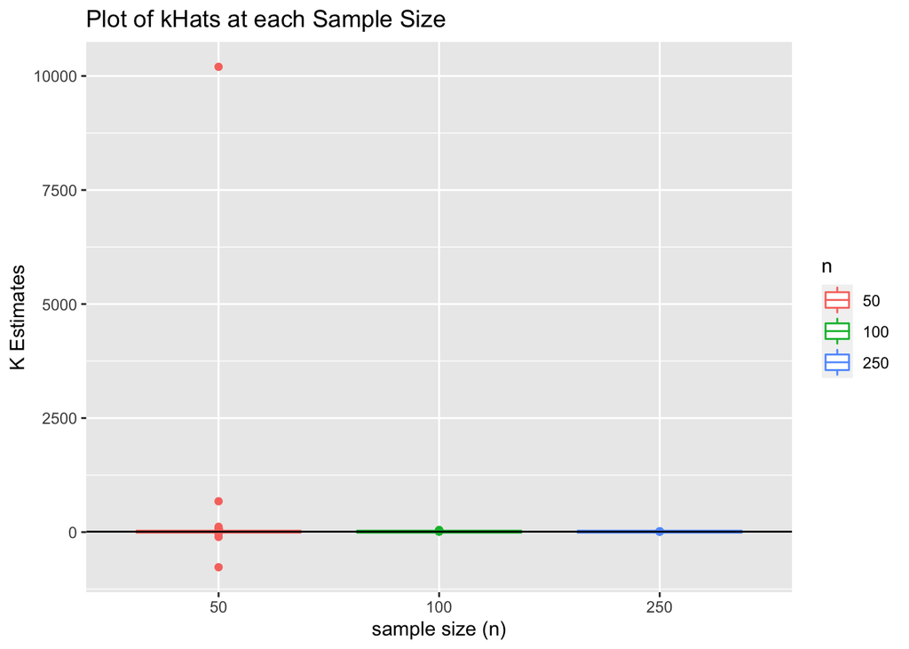

```r
#when n=50
set.seed(2)
randomSamples = list(replicate(1000,rbinom(50,10,.4)))

randomSamplesDF = data.frame(randomSamps = randomSamples)

randomSampleDF = t(randomSamplesDF)

estimatedKHats50 = apply(randomSampleDF,1,estimateKHat)

estimatedPHats = apply(randomSampleDF,1,estimatePHat)

#when n=100
set.seed(2)
randomSamples = list(replicate(1000,rbinom(100,10,.4)))

randomSamplesDF = data.frame(randomSamps = randomSamples)

randomSampleDF = t(randomSamplesDF)

estimatedKHats100 = apply(randomSampleDF,1,estimateKHat)

estimatedPHats = apply(randomSampleDF,1,estimatePHat)

#when n = 250

set.seed(2)
randomSamples = list(replicate(1000,rbinom(250,10,.4)))

randomSamplesDF = data.frame(randomSamps = randomSamples)

randomSampleDF = t(randomSamplesDF)

estimatedKHats250 = apply(randomSampleDF,1,estimateKHat)

estimatedPHats = apply(randomSampleDF,1,estimatePHat)


library(ggplot2)
vecKHats = c(estimatedKHats50,estimatedKHats100,estimatedKHats250)
ens = c(rep(50,1000),rep(100,1000),rep(250,1000))

kHatDF = data.frame(kHats = vecKHats,n = ens)
kHatDF$n = as.factor(kHatDF$n)

kHatBoxPlot <- ggplot(kHatDF) +
  geom_boxplot(mapping = aes(x=n, y=kHats,color = n))+
  geom_hline(yintercept = 10)+
  labs(title="Plot of kHats at each Sample Size ",x="sample size (n)", y = "K Estimates")

kHatBoxPlot
```

**b** *k̂ can obtain values that are far away from the true value of the parameter when the sample size is small and the box plots might not be particularly informative in such a situation. Remove the estimates from the plot that are outside of the interval [0,50]so that the box plots are more informative (4 points).*

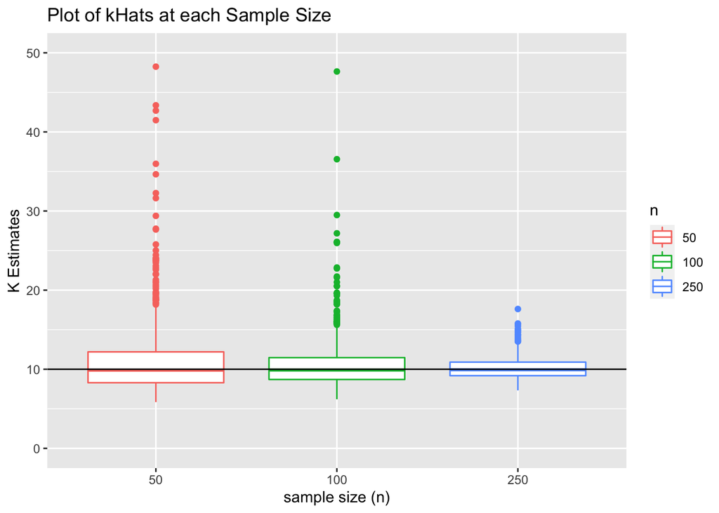

```r
kHatBoxPlotRestricted <- ggplot(kHatDF) +
  geom_boxplot(mapping = aes(x=n, y=kHats,color = n))+
  geom_hline(yintercept = 10)+
  labs(title="Plot of kHats at each Sample Size ",x="sample size (n)", y = "K Estimates")+
  coord_cartesian(ylim = c(0, 50))

kHatBoxPlotRestricted
```

**c** *Make the same plot with three box plots for the estimates of the parameter p (b part does not apply here) (2 points).*

```r
#when n=50
set.seed(2)
randomSamples = list(replicate(1000,rbinom(50,10,.4)))

randomSamplesDF = data.frame(randomSamps = randomSamples)

randomSampleDF = t(randomSamplesDF)

estimatedKHats50 = apply(randomSampleDF,1,estimateKHat)
which.max(estimatedKHats50)
```

```
## randomSamps.622
##             622
```

```r
estimatedPHats50 = apply(randomSampleDF,1,estimatePHat)



#when n=100
set.seed(2)
randomSamples = list(replicate(1000,rbinom(100,10,.4)))

randomSamplesDF = data.frame(randomSamps = randomSamples)

randomSampleDF = t(randomSamplesDF)

estimatedKHats100 = apply(randomSampleDF,1,estimateKHat)

estimatedPHats100 = apply(randomSampleDF,1,estimatePHat)




#when n = 250

set.seed(2)
randomSamples = list(replicate(1000,rbinom(250,10,.4)))

randomSamplesDF = data.frame(randomSamps = randomSamples)

randomSampleDF = t(randomSamplesDF)

estimatedKHats250 = apply(randomSampleDF,1,estimateKHat)

estimatedPHats250 = apply(randomSampleDF,1,estimatePHat)

vecPHats = c(estimatedPHats50,estimatedPHats100,estimatedPHats250)
pHatDF = data.frame(pHats = vecPHats,n = ens)
pHatDF$n = as.factor(pHatDF$n)
library(dplyr)
```

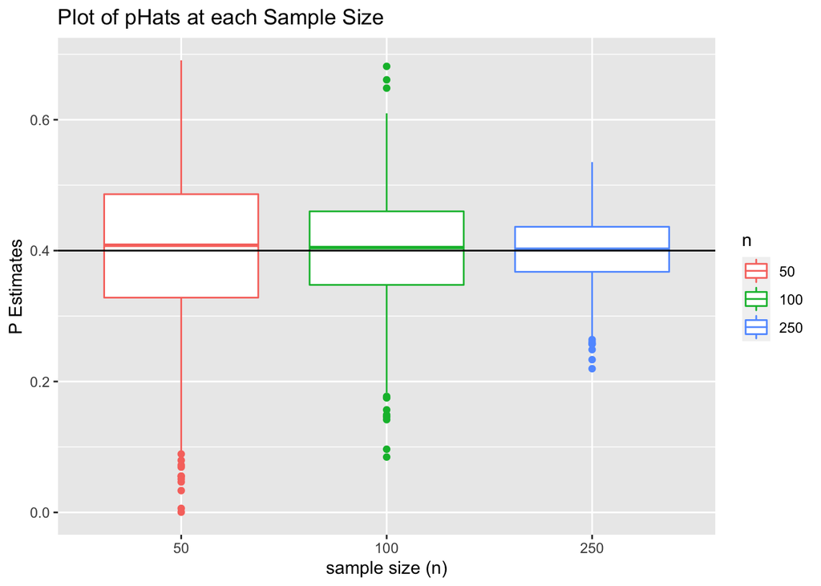

```r
pHatDF = pHatDF %>%
  filter(pHats >= 0)



pHatBoxPlot <- ggplot(pHatDF) +
  geom_boxplot(mapping = aes(x=n, y=pHats,color = n))+
  geom_hline(yintercept = .4)+
  labs(title="Plot of pHats at each Sample Size ",x="sample size (n)", y = "P Estimates")


pHatBoxPlot
```